# The Effect of Clean Energy Access on Death Rates Across the Globe (2000-2019)

Sarah Beasley

05/06/2022

```r
library(tidyverse)
library(tidytuesdayR)
library(ggthemes)
library(viridis)
library(ggthemr)
library(tidymodels)
library(baguette)
library(rpart.plot)
library(ggrepel)
```

# Indoor Air Pollution Worldwide

Indoor air pollution is one of the many risk factors for lung/heart diseases and causes of premature death. This pollution is mostly caused by burning solid fuels (i.e., firewood, vegetation debris, or excrement) indoors, when one doesn’t have access to clean fuels for daily use (i.e. cooking and/or heating).

This is a big problem, mostly in lower-income countries that do not have the resources for clean energy.

This data comes from **Tidy Tuesday** on Github, more specifically from *OurWorldInData.org*, and includes six different datasets involving different countries throughout the years (namely 2000-2019), and their different Gross Domestic Products (GDPs), access to clean fuel, death rates/percents/numbers that are from indoor pollution, and other related things. In this project, we will be using four of the six datasets (`fuel_gdp`, `death_source`, `indoor_pollution`, and `death_timeseries`).

**Note**: Since there are many missing values in a couple of the dataset, we will focus mainly on the time period of 2000 to 2019, even though the datasets have some data before that time period.

In this project, we will try to answer the questions:

- Which countries have decreased their indoor pollution deaths (by percentage) the most from 2000 to 2019?
- Can we predict the death rate through other factors of the country such as the year, GDP, and clean fuel access? If so what type of predictive model is best?

# Clean Data

For these datasets, there are a couple things that need to be cleaned up, or in this case, wrangled and combined. In this section, we will be cleaning up the `death_timeseries` and `fuel_gdp` datasets, as well as combining all of the four datasets to make the data easier to access and show.

First off, let’s wrangle some data.

## Wrangling and Cleaning

The `death_timeseries` dataset has some unnecessary numbers that we don’t need, namely the 5th and 6th column, that compares the certain year to the 2019 data… which we already have as a separate row in the dataset. Since these numbers are somewhat useless in this case, we’ll get rid of them, and instead, replace them with the difference between the number of deaths in that certain year and that of 2019.

To do this, we’ll create a new column with the `mutate` function, and after, select the columns that actually matter, and create a new dataset called `death_time`.

```r
death_time = death_timeseries %>%
  mutate(death_diff = deaths_from_pol_risk_number - deaths_in_2019) %>%
  select(Entity, Code, year, deaths_from_pol_risk_number, death_diff, Continent)
```

This new dataset is a little less repetitive, and easily shows us the change between a certain year and 2019 in the amount of deaths that are potentially due to indoor air pollution.

For the `fuel_gdp` dataset, there are a lot of unnecessary years involved in the data, such as year -1000 or the year 850, which aren’t relevant to the data we are looking for. Therefore, we are only going to keep any rows with the year being between 2000 and 2019.

To do this, we will use the `filter` function and make another “new” dataset named `fuel_gdp_new`.

```r
fuel_gdp_new = fuel_gdp %>%
  filter(Year %in% 2000:2019)
```

This will make it easier to compare with the data in the other datasets, and also make it easier to combine the data.

## Combining Datasets

One of the first things we’d like to do in this case, since there are multiple datasets, is to create a joined dataset that includes all of the different data to easily make graphs.

To do this, we would code the following:

```r
pol_total = indoor_pollution %>%
  inner_join(death_source, by = c("Entity", "Code", "Year"))
```

```r
pol_total_1 = pol_total %>%
  inner_join(death_time, by = c("Entity", "Code", "Year" = "year"))
```

This code chunk combines the previous combination of the `indoor_pollution` and `death_source` datasets and combines it with the `death_time` dataset. We had to include the `"Year" = "year"` portion due to the fact that the `Year` column was named slightly different (lowercase) than the `pol_total` dataset had it.

The following code chunk will combine the remaining `fuel_gdp_new` dataset with the previous three.

```r
pol_total_2 = pol_total_1 %>%
  inner_join(fuel_gdp_new, by = c("Entity", "Code", "Year")) %>%
  filter(Year %in% 2000:2019) %>%
  select(-Continent.x, - Continent.y)
```

```r
pol_total_3 = pol_total_1 %>%
  inner_join(fuel_gdp_new, by = c("Entity", "Code", "Year")) %>%
  filter(Year %in% 2000:2019) %>%
  select(-Continent.x, - Continent.y) %>%
  na.omit()
```

This last chunk is what we will use later on for our predictive model. This portion of the code gets rid of all of the `NA` rows in our dataset, allowing us to fully predict our data properly between 2000 and 2019.

# The Difference in Death Percentage

Now that we’ve combined the data into one, cohesive dataset, let’s look into answering our first question:

Which countries have decreased their indoor pollution deaths (by percentage) the most from 2000 to 2019?

Let’s take a look at a graphic.

To do this, first we will have to `filter` all of the rows from 2000 and 2019 in our dataset.

This will give us only the rows that include the `Year` column as either 2000 or 2019.

Next, we have to calculate the difference. How would we do that? This code involves the use of the `diff` and `lag` functions, which will take whatever you `group_by` (in this case, we will be grouping by `Entity`, which is the Country), and then calculate the difference (hence the name `diff`) between the values inside of that column (in this case the death percentage), and put it into a new column that the `mutate` function creates. However, since we only want to calculate certain differences between one country’s death percentage over the span of 2000 to 2019, we will use the `lag` function, which will separate the values of each country, making sure we keep each country’s data separate from one another.

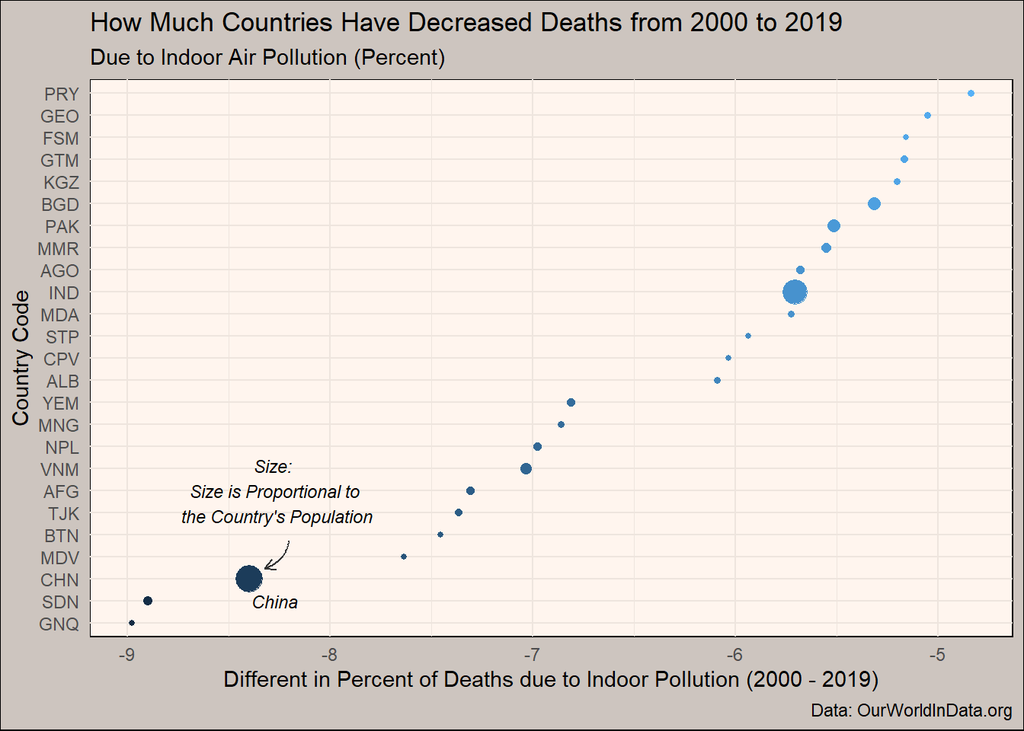

```r
pol_total_2 %>%
  filter(Year == c(2000, 2019)) %>%
  group_by(Entity) %>%
  mutate(perc_diff = diff(death_from_pol_risk_percent, lag = 1)) %>%
  select(Entity, Code, Year, death_from_pol_risk_percent, perc_diff, population_est) %>%
  na.omit() %>%
  ungroup() %>%
  filter(Year == 2000) %>%
  slice_min(order_by = perc_diff, n = 25) %>%
  ggplot(aes(y = perc_diff, x = fct_reorder(Code, perc_diff), color = perc_diff, size = population_est)) +
  geom_point()+
  coord_flip() +
  theme_minimal() +
  annotate("text", x = 7, y = -8.27, fontface = "italic",
           size = 3, color = "black",
           label = "Size: \n Size is Proportional to \n the Country's Population") +
    annotate("text", x = 2, y = -8.27, fontface = "italic",
           size = 3, color = "black",
           label = "China") +
  geom_curve(x = 4.75, xend = 3.5, y = -8.2, yend = -8.32,
             arrow = arrow(length = unit(0.08, "inch")), size = 0.5,
             color = "gray20", curvature = -0.3) +
  theme(legend.position = "none", panel.background = element_rect(fill = "seashell"), panel.grid = element_line(color = "seashell2"), plot.background = element_rect(fill = "seashell3")) +
  labs(y = "Different in Percent of Deaths due to Indoor Pollution (2000 - 2019)", x = "Country Code", title = "How Much Countries Have Decreased Deaths from 2000 to 2019", subtitle = "Due to Indoor Air Pollution (Percent)", caption = "Data: OurWorldInData.org")
```

There are many different things to discuss regarding this graphic. First off, the x-axis (which is coded as the y-axis), shows the different percentages that the countries (on the y-axis) have decreased their death rate by in regards to indoor pollution. The color also represents this percentage, the darker the color being the more difference there was in the death percentage from 2000 to 2019, and the size of the points is proportional to the country’s population. Overall, this graphic tells us which countries have decreased their death percentages the most since 2000, namely *Equatorial Guinea, Sudan, and China* with decreases of around *8-9 percent* over the 19 year span. All three of these data points are considerably above the rest of the data, with almost a percent between China and the 4th place country, the Maldives.

With this graphic, though, we are missing some information: is there a relationship between the decrease in death percentage and the change in clean fuel access and GDP per capita?

To do this, let’s make another data graphic. The fuel access dataset for this project is only complete for all countries up to *2015*. Since the data for fuel access isn’t completed up to 2019, this graphic will give us a general idea up until 2015.

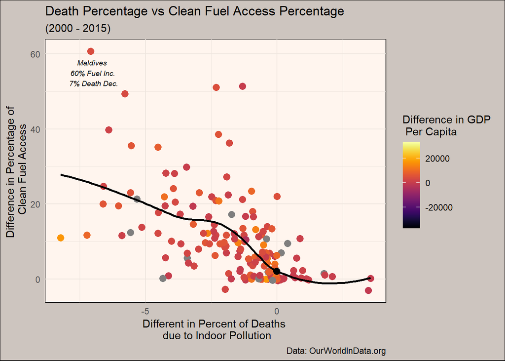

```r
pol_total_2 %>%
  filter(Year == c(2000, 2015)) %>%
  group_by(Entity) %>%
  mutate(perc_diff = diff(death_from_pol_risk_percent, lag = 1), fuel_diff = diff(fuel_access_percent, lag = 1), gdp_diff = diff(gdp_per_capita, lag = 1)) %>%
  select(Entity, Code, Year, death_from_pol_risk_percent, perc_diff, gdp_per_capita, gdp_diff, fuel_access_percent, fuel_diff) %>%
  ungroup() %>%
  filter(Year == 2015) %>%
  ggplot(aes(x = perc_diff, y = fuel_diff)) +
  geom_point(aes(color = gdp_diff), size = 3) +
  geom_smooth(se = FALSE, color = "black") +
  theme_minimal() +
  annotate("text", x = -7, y = 55, fontface = "italic",
           size = 2.5, color = "black",
           label = "Maldives \n 60% Fuel Inc. \n 7% Death Dec.") +
  scale_color_viridis(option = "B") +
  theme(panel.background = element_rect(fill = "seashell"), panel.grid = element_line(color = "seashell2"), plot.background = element_rect(fill = "seashell3")) +
  labs(x = "Different in Percent of Deaths \n due to Indoor Pollution", y = "Difference in Percentage of \n Clean Fuel Access", color = "Difference in GDP \n Per Capita ", title = "Death Percentage vs Clean Fuel Access Percentage", subtitle = "(2000 - 2015)", caption = "Data: OurWorldInData.org")
```

This graphic has one main point: as the difference in death percentage increases, the difference in fuel access percent decreases. What this tells us is that, in general, *the higher the increase in clean fuel access, the more the death percentage will decrease*.

Looking at the specifics of this graphic, the x-axis tells us how much the death percentage has increased/decreased from 2000 to 2015, while the y-axis explains how much the fuel access of citizens has changed between 2000 and 2015. The color shows us how much the GDP per capita has increased or decreased in the countries as well, giving us an extra factor to examine. The lighter the color, the higher the increase in GDP.For example, the highest point on the left of this graph is the Maldives with a fuel access percent increase of around 60% and a death percentage decrease of around 7%.

In regards to the color, one exception is the grey points. These points represent countries with no GDP value in the dataset.

This graph tells us that the GDP and fuel access differences are not extremely related, but that the fuel access and death percentage differences are related.

# Making Predictions

One important part of modeling is being able to *make predictions* based on a testing set. To be able to make predictions, we first have to see what helps predict the data the best, which means we’ll have to do some **exploratory analysis**.

Remember, the question we will be attempting to answer is: Can we predict the death rate through other factors of the country such as the year, GDP, and clean fuel access? If so what type of predictive model is best?

## Exploratory Analysis

Let’s test some of the variables in the dataset to see their relationship (if any) with the death rate.

First, let’s make a few scatterplots of the different variables to see if any are good predictors of the death rate.

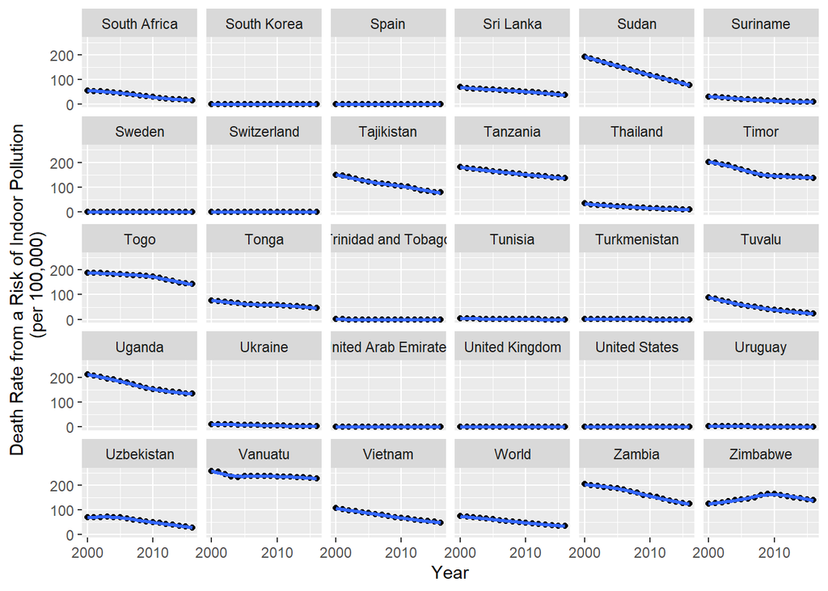

```r
pol_total_3 %>%
  slice_max(order_by = Entity, n = 500) %>%
  ggplot(aes(x = Year, y = death_from_pol_risk_rate)) +
  geom_point() +
  geom_smooth(se = FALSE) +
  facet_wrap( ~ Entity, nrow = 5) +
  theme(legend.position = "") +
  scale_x_continuous(breaks = c(2000, 2010, 2020)) +
  labs(y = "Death Rate from a Risk of Indoor Pollution \n (per 100,000)")
```

Let’s look at some other variables, such as the `fuel_access_percent` and the `gdp_per_capita`.

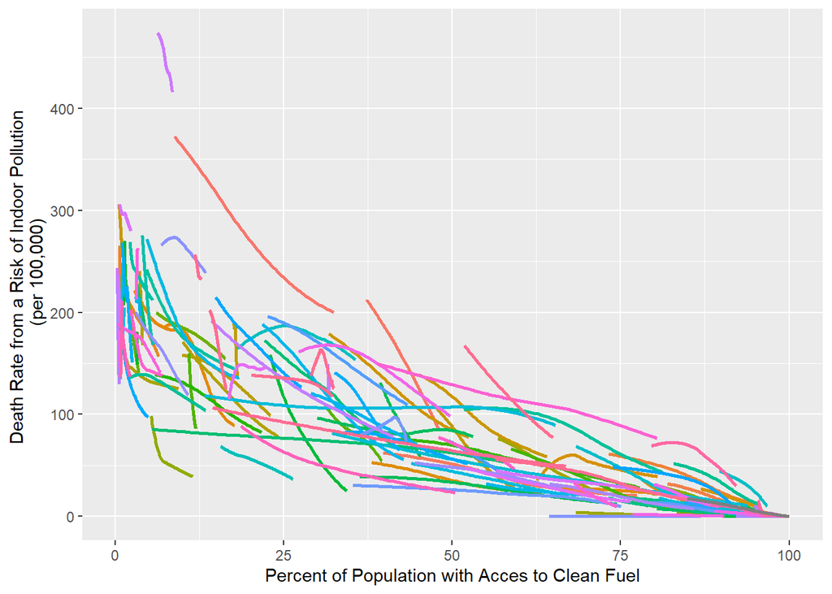

```r
pol_total_2 %>%
  ggplot(aes(x = fuel_access_percent, y = death_from_pol_risk_rate, color = Code)) +
  geom_smooth(se = F) +
  theme(legend.position = "") +
  labs(y = "Death Rate from a Risk of Indoor Pollution \n (per 100,000)", x = "Percent of Population with Acces to Clean Fuel")
```

The graph above shows the relationship between the percent of each country’s population that has access to clean fuel, and the death rate of those who have risk of indoor pollution (per 100,000). This graphic tells us clearly that, in general, the two variables have an inverse relationship, meaning that as the percentage increases, the death rate decreases. This variable will be useful to us in our predictive modeling process.

Now, let’s see the relationship between the death rate and the GDP per capita of the country.

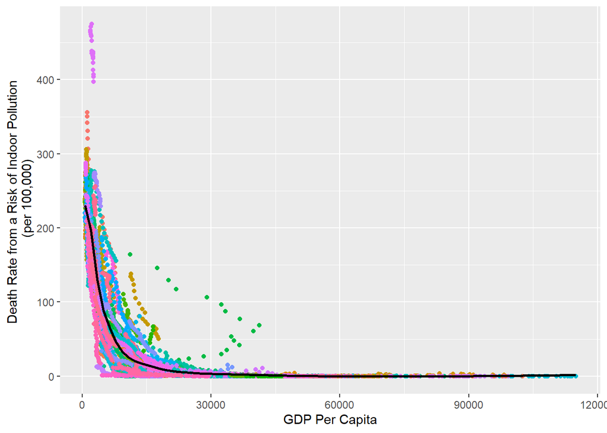

```r
pol_total_2 %>%
  ggplot(aes(x = gdp_per_capita, y = death_from_pol_risk_rate)) +
  geom_point(aes(color = Code)) +
  geom_smooth(se= F, color = "black") +
  theme(legend.position = "") +
  labs(y = "Death Rate from a Risk of Indoor Pollution \n (per 100,000)", x = "GDP Per Capita")
```

The graph above is greatly skewed, however, it might be a useful addition to our predictive models since GDP can determine the death rate in general.

After further exploratory analysis, the other variables in the dataset do not have a significant relationship with the death rate aside from the death percentage. However, since the death percentage is almost directly correlated since they are similar values, we probably should not include this variable.

Therefore, the predictive models that will attempt to predict the death rate due to a risk of indoor pollution will include the following variables: Country/Country code, year, GDP per capita, and percent of population with access to clean fuels.

## Predictive Modeling Differences

Now that we have our variables, let’s get into the predictive modeling! In this section, we will use different predictive models to see what is the best possible model to predict the death rate.

To do this, we will use a *training* set to see how well a model can predict the *testing* set. We will use the `initial_split()` function to create these two sets by splitting the data into two sections, with the *training* set being larger than the *testing* set. The outputted rMSE value will tell us how well the predictive model works.

Let’s look at some models.

### Linear Regression Model

```r
set.seed(13)
pol_split = initial_split(pol_total_3)
pol_train = training(pol_split)
pol_test = testing(pol_split)

pol_lm = linear_reg() %>%
  fit(death_from_pol_risk_rate ~ Code + Year + fuel_access_percent + gdp_per_capita,
    data = pol_train)

pred_lm = pol_lm %>%
  predict(new_data = pol_test)

pol_test %>%
  mutate(death_rate_pred = pred_lm$.pred) %>%
  rmse(truth = death_from_pol_risk_rate, estimate = death_rate_pred)
```

```
## # A tibble: 1 x 3
##   .metric .estimator .estimate
##   <chr>   <chr>          <dbl>
## 1 rmse    standard        12.6
```

The first model we will look at is the **linear regression** model. This model makes predictions based off of a straight line. The estimated rMSE is good, but let’s see what else the other models have to offer.

### Decision Tree

```r
set.seed(13)
pol_split = initial_split(pol_total_3)
pol_train = training(pol_split)
pol_test = testing(pol_split)

pol_tree = decision_tree() %>%
  set_mode(mode = "regression") %>%
  fit(death_from_pol_risk_rate ~ Code + Year + fuel_access_percent + gdp_per_capita,
    data = pol_train)

pred_tree = pol_tree %>%
  predict(new_data = pol_test)

#rpart.plot(pol_tree$fit, roundint = FALSE)

pol_test %>%
  mutate(death_rate_pred_2 = pred_tree$.pred) %>%
  rmse(truth = death_from_pol_risk_rate, estimate = death_rate_pred_2)
```

```
## # A tibble: 1 x 3
##   .metric .estimator .estimate
##   <chr>   <chr>          <dbl>
## 1 rmse    standard        23.1
```

The second model we will look at is the **decision tree** model. This model is similar to a flowchart and works through splitting the variables into smaller regions with target values. Overall, this rMSE value is considerably higher than the linear regression model, so as of now, the linear regression model is the best.

### Random Forests

```r
set.seed(13)
pol_split = initial_split(pol_total_3)
pol_train = training(pol_split)
pol_test = testing(pol_split)

pol_rf = rand_forest() %>%
  set_mode(mode = "regression") %>%
  fit(death_from_pol_risk_rate ~ Code + Year + fuel_access_percent + + gdp_per_capita,
    data = pol_train)

pred_rf = pol_rf %>%
  predict(new_data = pol_test)

pol_test %>%
  mutate(death_rate_pred_3 = pred_rf$.pred) %>%
  rmse(truth = death_from_pol_risk_rate, estimate = death_rate_pred_3)
```

```
## # A tibble: 1 x 3
##   .metric .estimator .estimate
##   <chr>   <chr>          <dbl>
## 1 rmse    standard        11.3
```

The third model we will look at is the **random forest** model. This model works like a bagged decision tree, but the splitting of variables is based off of a random subset each time we use it. This adds to the variability of the training set, which will help predictive outcomes, which in this case, helped quite a bit since it is the lowest rMSE so far.

### Boosted Model

```r
set.seed(13)
pol_split = initial_split(pol_total_3)
pol_train = training(pol_split)
pol_test = testing(pol_split)

pol_boost = boost_tree() %>%
  set_mode(mode = "regression") %>%
  fit(death_from_pol_risk_rate ~ Code + Year + fuel_access_percent + gdp_per_capita,
    data = pol_train)

pred_boost = pol_boost %>%
  predict(new_data = pol_test)

pol_test %>%
  mutate(death_rate_pred_5 = pred_boost$.pred) %>%
  rmse(truth = death_from_pol_risk_rate, estimate = death_rate_pred_5)
```

```
## # A tibble: 1 x 3
##   .metric .estimator .estimate
##   <chr>   <chr>          <dbl>
## 1 rmse    standard        12.6
```

The last model we will look at is the **boosted** model. This model is also tree-based, however it more “shallow”, and improves upon itself as the tree grows. However, in this case, the boosted model is not a better predictor of the death rate, with an rMSE of 12.59.

## The Best Model?

To figure out the best model, we must look at the output rMSE value. The general rule of thumb that we follow is that *the lower the rMSE, the better the predictive model*. Therefore, we can conclude that our best model will be the **random forest** model, that gives us an rMSE of 11.28.

This rMSE value represents the *square root of the variance of the residuals*, meaning that the value of 11.28 is roughly the average distance between the observed data values and the predicted data values. In general, the 11.28 is the average error in the predicted death rate of this model.

## Cross Validation

Now that we have determined our best model, let’s use cross-validation to make sure that the model is valid. To conduct Monte-Carlo Cross Validation, we have to conduct the predictive modeling process 10 times, but with a *fixed proportion of 0.9*. We then take the average of the 10 rMSEs that we have outputted.

For the sake of clarity, one of the ten sample’s codes will be included instead of all ten codes.

```r
set.seed(19)
pol_split = initial_split(pol_total_3, prop = 0.9)
pol_train = training(pol_split)
pol_test = testing(pol_split)

pol_rf = rand_forest() %>%
  set_mode(mode = "regression") %>%
  fit(death_from_pol_risk_rate ~ Code + Year + fuel_access_percent + + gdp_per_capita,
    data = pol_train)

pred_rf = pol_rf %>%
  predict(new_data = pol_test)

pol_test %>%
  mutate(death_rate_pred_3 = pred_rf$.pred) %>%
  rmse(truth = death_from_pol_risk_rate, estimate = death_rate_pred_3)
```

```
## # A tibble: 1 x 3
##   .metric .estimator .estimate
##   <chr>   <chr>          <dbl>
## 1 rmse    standard        8.95
```

```r
mean(c(9.638436, 11.29759, 12.21982, 9.760811, 8.65747, 11.03899, 10.53024, 9.8006, 10.56328, 8.947337))
```

```
## [1] 10.24546
```

Since the average rMSE is not far off from the original rMSE above, we can consider this model to be valid and not over-fitted.

# Conclusions and Further Questions

Indoor air pollution is a prominent issue, however, the death rates and percentages have gone down over the past 19 years. Clean fuel access is a **very** important factor in handling indoor air pollution and lowering the risk of many lung and heart diseases. There are many other factors involved (i.e., world events, other economic properties, poverty, smoking percentage, healthcare access, and/or access to safe water/food) that are not in this project and still need to be explored in order to create a better predictive model of death rate due to indoor pollution in different countries.